# Prediction First Pass

lib

11/05/2020

# Importing the RT data sets we will be working with.

Below we are importing each data set and modifying the participant numbers to apply to the appropriate person. As we have had to extract the data in eyedry in batches of ~20 per extraction the participant numbers are not related to the actual participants. Here we are fixing this as well as importing the data.

```r
#import the data set batch 1
FP_ED_batch1_corr <- read_csv("Duncans-Grant-master/FP_ED/FP_ED_batch1_corr.csv")
#Rename the participant numbers in the batches back to their original participant numbers.
FP_ED_batch1_corr$subj[FP_ED_batch1_corr$subj == 20] <-"38"
FP_ED_batch1_corr$subj[FP_ED_batch1_corr$subj == 19] <-"36"
FP_ED_batch1_corr$subj[FP_ED_batch1_corr$subj == 18] <-"35"
FP_ED_batch1_corr$subj[FP_ED_batch1_corr$subj == 17] <-"34"
FP_ED_batch1_corr$subj[FP_ED_batch1_corr$subj == 16] <-"32"
FP_ED_batch1_corr$subj[FP_ED_batch1_corr$subj == 15] <-"30"
FP_ED_batch1_corr$subj[FP_ED_batch1_corr$subj == 14] <-"28"
FP_ED_batch1_corr$subj[FP_ED_batch1_corr$subj == 13] <-"26"
FP_ED_batch1_corr$subj[FP_ED_batch1_corr$subj == 12] <-"24"
FP_ED_batch1_corr$subj[FP_ED_batch1_corr$subj == 11] <-"22"
FP_ED_batch1_corr$subj[FP_ED_batch1_corr$subj == 10] <-"20"
FP_ED_batch1_corr$subj[FP_ED_batch1_corr$subj == 9] <-"18"
FP_ED_batch1_corr$subj[FP_ED_batch1_corr$subj == 8] <-"16"
FP_ED_batch1_corr$subj[FP_ED_batch1_corr$subj == 7] <-"14"
FP_ED_batch1_corr$subj[FP_ED_batch1_corr$subj == 6] <-"12"
FP_ED_batch1_corr$subj[FP_ED_batch1_corr$subj == 5] <-"10"
FP_ED_batch1_corr$subj[FP_ED_batch1_corr$subj == 4] <-"8"
FP_ED_batch1_corr$subj[FP_ED_batch1_corr$subj == 3] <-"6"
FP_ED_batch1_corr$subj[FP_ED_batch1_corr$subj == 2] <-"4"
FP_ED_batch1_corr$subj[FP_ED_batch1_corr$subj == 1] <-"2"

#import the data set batch 2B
FP_ED_batch2B_corr <- read_csv("Duncans-Grant-master/FP_ED/FP_ED_batch2B_corr.csv")
#Rename the participant numbers in the batches back to their original participant numbers.
FP_ED_batch2B_corr$subj[FP_ED_batch2B_corr$subj == 19] <-"71"
FP_ED_batch2B_corr$subj[FP_ED_batch2B_corr$subj == 18] <-"70"
FP_ED_batch2B_corr$subj[FP_ED_batch2B_corr$subj == 17] <-"69"
FP_ED_batch2B_corr$subj[FP_ED_batch2B_corr$subj == 16] <-"68"
FP_ED_batch2B_corr$subj[FP_ED_batch2B_corr$subj == 15] <-"66"
FP_ED_batch2B_corr$subj[FP_ED_batch2B_corr$subj == 14] <-"64"
FP_ED_batch2B_corr$subj[FP_ED_batch2B_corr$subj == 13] <-"62"
FP_ED_batch2B_corr$subj[FP_ED_batch2B_corr$subj == 12] <-"60"
FP_ED_batch2B_corr$subj[FP_ED_batch2B_corr$subj == 11] <-"58"
FP_ED_batch2B_corr$subj[FP_ED_batch2B_corr$subj == 10] <-"56"
FP_ED_batch2B_corr$subj[FP_ED_batch2B_corr$subj == 9] <-"54"
FP_ED_batch2B_corr$subj[FP_ED_batch2B_corr$subj == 8] <-"50"
FP_ED_batch2B_corr$subj[FP_ED_batch2B_corr$subj == 7] <-"48"
FP_ED_batch2B_corr$subj[FP_ED_batch2B_corr$subj == 6] <-"46"
FP_ED_batch2B_corr$subj[FP_ED_batch2B_corr$subj == 5] <-"44"
FP_ED_batch2B_corr$subj[FP_ED_batch2B_corr$subj == 4] <-"43"
FP_ED_batch2B_corr$subj[FP_ED_batch2B_corr$subj == 3] <-"42"
FP_ED_batch2B_corr$subj[FP_ED_batch2B_corr$subj == 2] <-"40"
FP_ED_batch2B_corr$subj[FP_ED_batch2B_corr$subj == 1] <-"39"

#import the data set batch 3
FP_ED_batch3_corr <- read_csv("Duncans-Grant-master/FP_ED/FP_ED_batch3_corr.csv")
#Rename the participant numbers in the batches back to their original participant numbers.
FP_ED_batch3_corr$subj[FP_ED_batch3_corr$subj == 21] <-"99"
FP_ED_batch3_corr$subj[FP_ED_batch3_corr$subj == 20] <-"95"
FP_ED_batch3_corr$subj[FP_ED_batch3_corr$subj == 19] <-"92"
FP_ED_batch3_corr$subj[FP_ED_batch3_corr$subj == 18] <-"91"
FP_ED_batch3_corr$subj[FP_ED_batch3_corr$subj == 17] <-"89"
FP_ED_batch3_corr$subj[FP_ED_batch3_corr$subj == 16] <-"87"
FP_ED_batch3_corr$subj[FP_ED_batch3_corr$subj == 15] <-"86"
FP_ED_batch3_corr$subj[FP_ED_batch3_corr$subj == 14] <-"85"
FP_ED_batch3_corr$subj[FP_ED_batch3_corr$subj == 13] <-"84"
FP_ED_batch3_corr$subj[FP_ED_batch3_corr$subj == 12] <-"83"
FP_ED_batch3_corr$subj[FP_ED_batch3_corr$subj == 11] <-"82"
FP_ED_batch3_corr$subj[FP_ED_batch3_corr$subj == 10] <-"81"
FP_ED_batch3_corr$subj[FP_ED_batch3_corr$subj == 9] <-"80"
FP_ED_batch3_corr$subj[FP_ED_batch3_corr$subj == 8] <-"79"
FP_ED_batch3_corr$subj[FP_ED_batch3_corr$subj == 7] <-"78"
FP_ED_batch3_corr$subj[FP_ED_batch3_corr$subj == 6] <-"77"
FP_ED_batch3_corr$subj[FP_ED_batch3_corr$subj == 5] <-"76"
FP_ED_batch3_corr$subj[FP_ED_batch3_corr$subj == 4] <-"75"
FP_ED_batch3_corr$subj[FP_ED_batch3_corr$subj == 3] <-"74"
FP_ED_batch3_corr$subj[FP_ED_batch3_corr$subj == 2] <-"73"
FP_ED_batch3_corr$subj[FP_ED_batch3_corr$subj == 1] <-"72"

#import the data set batch 4
FP_ED_batch4_error <- read_csv("Duncans-Grant-master/FP_ED/FP_ED_batch4_error.csv")
#Rename the participant numbers in the batches back to their original participant numbers.
FP_ED_batch4_error$subj[FP_ED_batch4_error$subj == 20] <-"41"
FP_ED_batch4_error$subj[FP_ED_batch4_error$subj == 19] <-"37"
FP_ED_batch4_error$subj[FP_ED_batch4_error$subj == 18] <-"35"
FP_ED_batch4_error$subj[FP_ED_batch4_error$subj == 17] <-"33"
FP_ED_batch4_error$subj[FP_ED_batch4_error$subj == 16] <-"31"
FP_ED_batch4_error$subj[FP_ED_batch4_error$subj == 15] <-"29"
FP_ED_batch4_error$subj[FP_ED_batch4_error$subj == 14] <-"27"
FP_ED_batch4_error$subj[FP_ED_batch4_error$subj == 13] <-"25"
FP_ED_batch4_error$subj[FP_ED_batch4_error$subj == 12] <-"23"
FP_ED_batch4_error$subj[FP_ED_batch4_error$subj == 11] <-"21"
FP_ED_batch4_error$subj[FP_ED_batch4_error$subj == 10] <-"19"
FP_ED_batch4_error$subj[FP_ED_batch4_error$subj == 9] <-"17"
FP_ED_batch4_error$subj[FP_ED_batch4_error$subj == 8] <-"15"
FP_ED_batch4_error$subj[FP_ED_batch4_error$subj == 7] <-"13"
FP_ED_batch4_error$subj[FP_ED_batch4_error$subj == 6] <-"11"
FP_ED_batch4_error$subj[FP_ED_batch4_error$subj == 5] <-"9"
FP_ED_batch4_error$subj[FP_ED_batch4_error$subj == 4] <-"7"
FP_ED_batch4_error$subj[FP_ED_batch4_error$subj == 3] <-"5"
FP_ED_batch4_error$subj[FP_ED_batch4_error$subj == 2] <-"3"
FP_ED_batch4_error$subj[FP_ED_batch4_error$subj == 1] <-"1"

#import the data set batch 5
FP_ED_batch5_error <- read_csv("Duncans-Grant-master/FP_ED/FP_ED_batch5_error.csv")
#Rename the participant numbers in the batches back to their original participant numbers.
FP_ED_batch5_error$subj[FP_ED_batch5_error$subj == 19] <-"98"
FP_ED_batch5_error$subj[FP_ED_batch5_error$subj == 18] <-"97"
FP_ED_batch5_error$subj[FP_ED_batch5_error$subj == 17] <-"96"
FP_ED_batch5_error$subj[FP_ED_batch5_error$subj == 16] <-"94"
FP_ED_batch5_error$subj[FP_ED_batch5_error$subj == 15] <-"93"
FP_ED_batch5_error$subj[FP_ED_batch5_error$subj == 14] <-"90"
FP_ED_batch5_error$subj[FP_ED_batch5_error$subj == 13] <-"88"
FP_ED_batch5_error$subj[FP_ED_batch5_error$subj == 12] <-"67"
FP_ED_batch5_error$subj[FP_ED_batch5_error$subj == 11] <-"65"
FP_ED_batch5_error$subj[FP_ED_batch5_error$subj == 10] <-"63"
FP_ED_batch5_error$subj[FP_ED_batch5_error$subj == 9] <-"61"
FP_ED_batch5_error$subj[FP_ED_batch5_error$subj == 8] <-"59"
FP_ED_batch5_error$subj[FP_ED_batch5_error$subj == 7] <-"57"
FP_ED_batch5_error$subj[FP_ED_batch5_error$subj == 6] <-"55"
FP_ED_batch5_error$subj[FP_ED_batch5_error$subj == 5] <-"53"
FP_ED_batch5_error$subj[FP_ED_batch5_error$subj == 4] <-"51"
FP_ED_batch5_error$subj[FP_ED_batch5_error$subj == 3] <-"49"
FP_ED_batch5_error$subj[FP_ED_batch5_error$subj == 2] <-"47"
FP_ED_batch5_error$subj[FP_ED_batch5_error$subj == 1] <-"45"
```

# Creating the RT data set we will be working with.

Below we are combining the 5 batches into 1 data set.

```r
#Let's combine the data
all_data <- rbind(FP_ED_batch1_corr, FP_ED_batch2B_corr, FP_ED_batch3_corr, FP_ED_batch4_error,
                  FP_ED_batch5_error)

# creating subj as a factor so we can actually combine our individual difference measures with this data set.

all_data$subj <- as.factor(all_data$subj)
```

# Importing the Individual difference (ID) data set we will be working with.

Below we are importing the ID data set that will be used to investigate our covariates. We are also renaming the participant column to subj so it can be successfully combined with our RT data set on the column subj.

```r
#Import Individual difference measures
ID_Measures <- read_csv("ID Measures.csv")
#View(ID_Measures)

# Rename Participabt in ID_measures to subj to be the same as current data set
ID_Measures <- rename(ID_Measures, subj = Participant)
ID_Measures$subj <- as.factor(ID_Measures$subj)
```

# Removing participants with missing data.

Below we are removing participants from the ID and RT data sets who have missing individual difference measures.

Additionally, this will ensure that when we next combined the two data sets they do not duplicate ID measures in the incorrect participant slot.

```r
#Remove participants with missing data
ID_Measures_removed <- ID_Measures %>% filter(subj != 16)
ID_Measures_removed <- ID_Measures_removed %>% filter(subj != 67)
ID_Measures_removed <- ID_Measures_removed %>% filter(subj != 34)
ID_Measures_removed <- ID_Measures_removed %>% filter(subj != 39)
ID_Measures_removed <- ID_Measures_removed %>% filter(subj != 42)
ID_Measures_removed <- ID_Measures_removed %>% filter(subj != 43)
ID_Measures_removed <- ID_Measures_removed %>% filter(subj != 44)
ID_Measures_removed <- ID_Measures_removed %>% filter(subj != 69)
ID_Measures_removed <- ID_Measures_removed %>% filter(subj != 70)
ID_Measures_removed <- ID_Measures_removed %>% filter(subj != 71)
ID_Measures_removed <- ID_Measures_removed %>% filter(subj != 72)
ID_Measures_removed <- ID_Measures_removed %>% filter(subj != 73)
ID_Measures_removed <- ID_Measures_removed %>% filter(subj != 74)
ID_Measures_removed <- ID_Measures_removed %>% filter(subj != 75)
ID_Measures_removed <- ID_Measures_removed %>% filter(subj != 76)
ID_Measures_removed <- ID_Measures_removed %>% filter(subj != 77)
ID_Measures_removed <- ID_Measures_removed %>% filter(subj != 78)
ID_Measures_removed <- ID_Measures_removed %>% filter(subj != 79)
ID_Measures_removed <- ID_Measures_removed %>% filter(subj != 80)
ID_Measures_removed <- ID_Measures_removed %>% filter(subj != 81)
ID_Measures_removed <- ID_Measures_removed %>% filter(subj != 82)
ID_Measures_removed <- ID_Measures_removed %>% filter(subj != 83)
ID_Measures_removed <- ID_Measures_removed %>% filter(subj != 84)
ID_Measures_removed <- ID_Measures_removed %>% filter(subj != 85)
ID_Measures_removed <- ID_Measures_removed %>% filter(subj != 86)
ID_Measures_removed <- ID_Measures_removed %>% filter(subj != 87)

#remove Participant who we do not have ID data for.
all_data_removed <- all_data %>% filter(subj != 16)
all_data_removed <- all_data_removed %>% filter(subj != 34)
all_data_removed <- all_data_removed %>% filter(subj != 39)
all_data_removed <- all_data_removed %>% filter(subj != 42)
all_data_removed <- all_data_removed %>% filter(subj != 43)
all_data_removed <- all_data_removed %>% filter(subj != 44)
all_data_removed <- all_data_removed %>% filter(subj != 67)
all_data_removed <- all_data_removed %>% filter(subj != 69)
all_data_removed <- all_data_removed %>% filter(subj != 70)
all_data_removed <- all_data_removed %>% filter(subj != 71)
all_data_removed <- all_data_removed %>% filter(subj != 72)
all_data_removed <- all_data_removed %>% filter(subj != 73)
all_data_removed <- all_data_removed %>% filter(subj != 74)
all_data_removed <- all_data_removed %>% filter(subj != 75)
all_data_removed <- all_data_removed %>% filter(subj != 76)
all_data_removed <- all_data_removed %>% filter(subj != 77)
all_data_removed <- all_data_removed %>% filter(subj != 78)
all_data_removed <- all_data_removed %>% filter(subj != 79)
all_data_removed <- all_data_removed %>% filter(subj != 80)
all_data_removed <- all_data_removed %>% filter(subj != 81)
all_data_removed <- all_data_removed %>% filter(subj != 82)
all_data_removed <- all_data_removed %>% filter(subj != 83)
all_data_removed <- all_data_removed %>% filter(subj != 84)
all_data_removed <- all_data_removed %>% filter(subj != 85)
all_data_removed <- all_data_removed %>% filter(subj != 86)
all_data_removed <- all_data_removed %>% filter(subj != 87)
all_data_removed <- all_data_removed %>% filter(subj != 88)
all_data_removed <- all_data_removed %>% filter(subj != 89)
all_data_removed <- all_data_removed %>% filter(subj != 90)
all_data_removed <- all_data_removed %>% filter(subj != 91)
all_data_removed <- all_data_removed %>% filter(subj != 92)
all_data_removed <- all_data_removed %>% filter(subj != 93)
all_data_removed <- all_data_removed %>% filter(subj != 94)
all_data_removed <- all_data_removed %>% filter(subj != 95)
all_data_removed <- all_data_removed %>% filter(subj != 96)
all_data_removed <- all_data_removed %>% filter(subj != 97)
all_data_removed <- all_data_removed %>% filter(subj != 98)
all_data_removed <- all_data_removed %>% filter(subj != 99)
```

# Next we will combine the two data sets together.

```r
# Add the ID's to the data frame
all_data_join <- inner_join(all_data_removed, ID_Measures_removed, by = "subj")
```

# Visualisation and analysis of *region 4* “the question”

Now that we’ve got a full data set ready to be analysed let’s first do some visualisation of the data to get a feel for how it is looking as well as the appropriate method. We might as well also relabel our conditions do they are easier to understand.

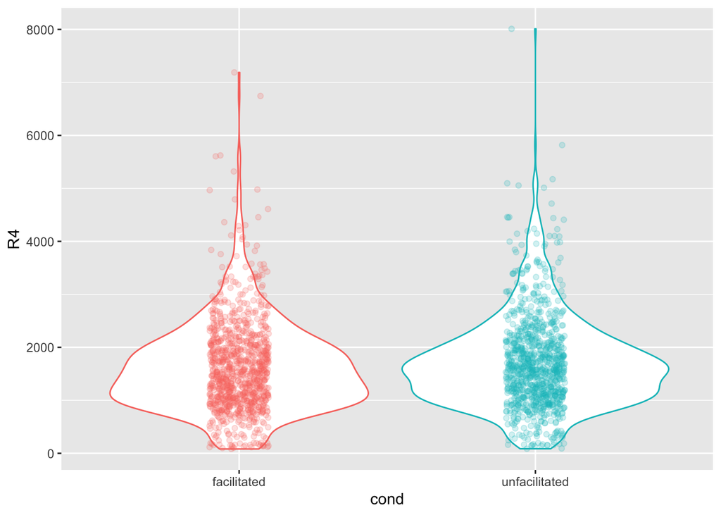

```r
all_data_join$cond <- recode(all_data_join$cond, "1" = "facilitated", "2" = "unfacilitated")

all_data_join$cond <- as.factor(all_data_join$cond)

#Let's start with Region 4 "the question"
# Throw away zeroes
all_data_join <- all_data_join %>% filter(R4 != 0)

# Visualise
all_data_join %>%
  ggplot(aes(x = cond, y = R4, colour = cond)) +
  geom_violin() +
  geom_jitter(alpha = .2, width = .1) +
  stat_summary(fun.data = "mean_cl_boot", colour = "black") +
  guides(colour = FALSE)
```

```r
all_data_join %>%
  group_by(cond) %>%
  summarise(mean(R4), sd(R4))
```

```
## # A tibble: 2 x 3
##   cond          `mean(R4)` `sd(R4)`
##   <fct>              <dbl>    <dbl>
## 1 facilitated        1631.     871.
## 2 unfacilitated      1706.     882.
```

```r
# Model assuming normality of residuals - singular fit error with more complex models
model.null <- lmer(R4 ~ (1 | subj) + (1 + cond | item), all_data_join)
model <- lmer(R4 ~ cond + (1 | subj) + (1 + cond | item), all_data_join)
summary(model)
```

```
## Linear mixed model fit by REML. t-tests use Satterthwaite's method [
## lmerModLmerTest]
## Formula: R4 ~ cond + (1 | subj) + (1 + cond | item)
##    Data: all_data_join
##
## REML criterion at convergence: 30563.5
##
## Scaled residuals:
##     Min      1Q  Median      3Q     Max
## -3.5522 -0.5245 -0.0934  0.4131  8.1246
##
## Random effects:
##  Groups   Name              Variance Std.Dev. Corr
##  subj     (Intercept)       279730   528.9
##  item     (Intercept)        49884   223.3
##           condunfacilitated  10564   102.8    -0.15
##  Residual                   442335   665.1
## Number of obs: 1915, groups:  subj, 60; item, 32
##
## Fixed effects:
##                   Estimate Std. Error      df t value Pr(>|t|)
## (Intercept)        1629.88      81.75   83.10  19.937   <2e-16 ***
## condunfacilitated    76.39      35.43   30.09   2.156   0.0392 *
## ---
## Signif. codes:  0 '***' 0.001 '**' 0.01 '*' 0.05 '.' 0.1 ' ' 1
##
## Correlation of Fixed Effects:
##             (Intr)
## condnfclttd -0.198
```

```r
anova(model, model.null)
```

```
## refitting model(s) with ML (instead of REML)
```

```
## Data: all_data_join
## Models:
## model.null: R4 ~ (1 | subj) + (1 + cond | item)
## model: R4 ~ cond + (1 | subj) + (1 + cond | item)
##            Df   AIC   BIC logLik deviance  Chisq Chi Df Pr(>Chisq)
## model.null  6 30600 30633 -15294    30588
## model       7 30597 30636 -15292    30583 4.4661      1    0.03457 *
## ---
## Signif. codes:  0 '***' 0.001 '**' 0.01 '*' 0.05 '.' 0.1 ' ' 1
```

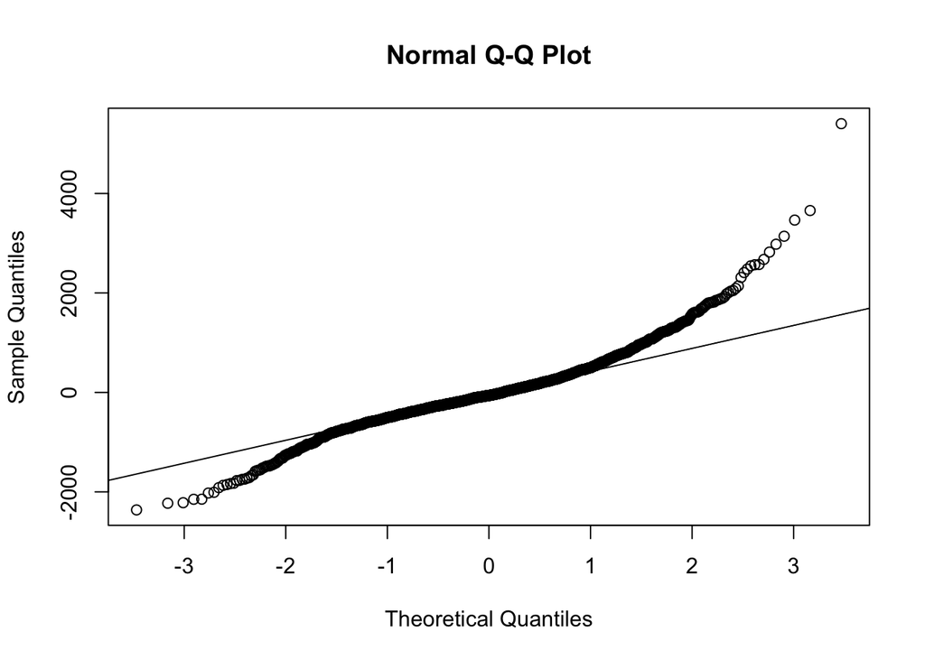

```r
qqnorm(residuals(model))
qqline(residuals(model))
```

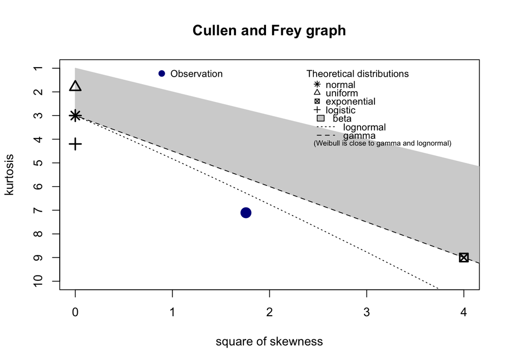

```
## summary statistics
## ------
## min:  82   max:  8011
## median:  1561
## mean:  1668.422
## estimated sd:  876.8836
## estimated skewness:  1.325456
## estimated kurtosis:  7.106687
```

```r
descdist(all_data_join$R4)
```

# Visualisation and analysis of *region 5* “the reply”

What does region 5 look like?

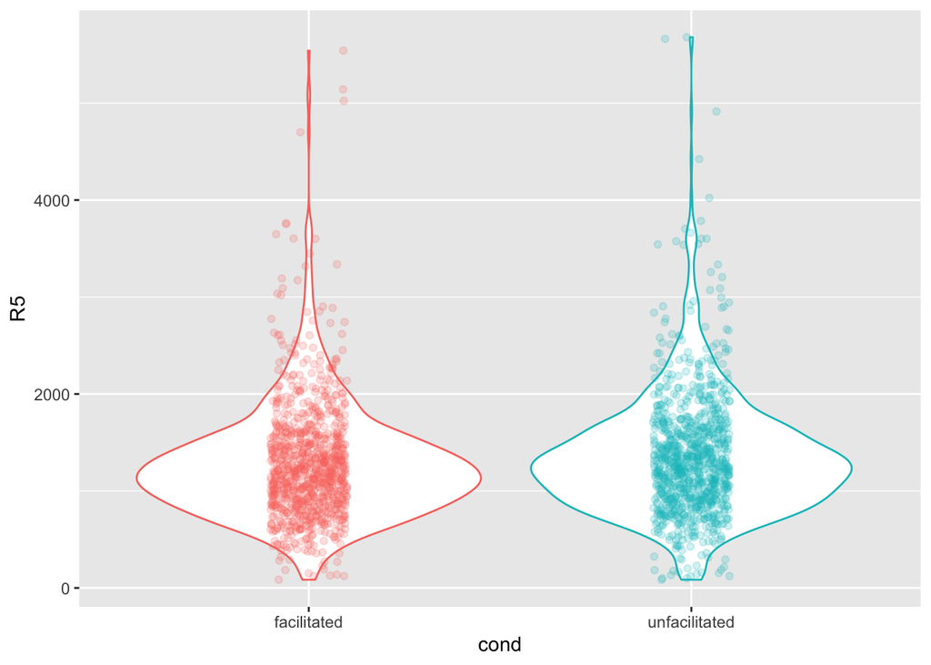

```r
all_data_join <- all_data_join %>% filter(R5 != 0)

# Visualise
all_data_join %>%
  ggplot(aes(x = cond, y = R5, colour = cond)) +
  geom_violin() +
  geom_jitter(alpha = .2, width = .1) +
  stat_summary(fun.data = "mean_cl_boot", colour = "black") +
  guides(colour = FALSE)
```

```r
all_data_join %>%
  group_by(cond) %>%
  summarise(mean(R5), sd(R5))
```

```
## # A tibble: 2 x 3
##   cond          `mean(R5)` `sd(R5)`
##   <fct>              <dbl>    <dbl>
## 1 facilitated        1286.     604.
## 2 unfacilitated      1352.     634.
```

```r
# Model assuming normality of residuals - singular fit error with more complex models
model.null <- lmer(R5 ~ (1 | subj) + (1 + cond | item), all_data_join)
model <- lmer(R5 ~ cond + (1 | subj) + (1 + cond | item), all_data_join)
summary(model)
```

```
## Linear mixed model fit by REML. t-tests use Satterthwaite's method [
## lmerModLmerTest]
## Formula: R5 ~ cond + (1 | subj) + (1 + cond | item)
##    Data: all_data_join
##
## REML criterion at convergence: 29029.7
##
## Scaled residuals:
##     Min      1Q  Median      3Q     Max
## -4.4843 -0.5294 -0.1056  0.3949  9.8484
##
## Random effects:
##  Groups   Name              Variance Std.Dev. Corr
##  subj     (Intercept)       144612   380.28
##  item     (Intercept)        34090   184.64
##           condunfacilitated   3681    60.67   0.51
##  Residual                   201056   448.39
## Number of obs: 1912, groups:  subj, 60; item, 32
##
## Fixed effects:
##                   Estimate Std. Error      df t value Pr(>|t|)
## (Intercept)        1286.45      60.71   84.61  21.189  < 2e-16 ***
## condunfacilitated    65.21      23.15   29.90   2.817  0.00851 **
## ---
## Signif. codes:  0 '***' 0.001 '**' 0.01 '*' 0.05 '.' 0.1 ' ' 1
##
## Correlation of Fixed Effects:
##             (Intr)
## condnfclttd -0.022
```

```r
anova(model, model.null)
```

```
## refitting model(s) with ML (instead of REML)
```

```
## Data: all_data_join
## Models:
## model.null: R5 ~ (1 | subj) + (1 + cond | item)
## model: R5 ~ cond + (1 | subj) + (1 + cond | item)
##            Df   AIC   BIC logLik deviance  Chisq Chi Df Pr(>Chisq)
## model.null  6 29067 29100 -14528    29055
## model       7 29062 29101 -14524    29048 7.2758      1   0.006989 **
## ---
## Signif. codes:  0 '***' 0.001 '**' 0.01 '*' 0.05 '.' 0.1 ' ' 1
```

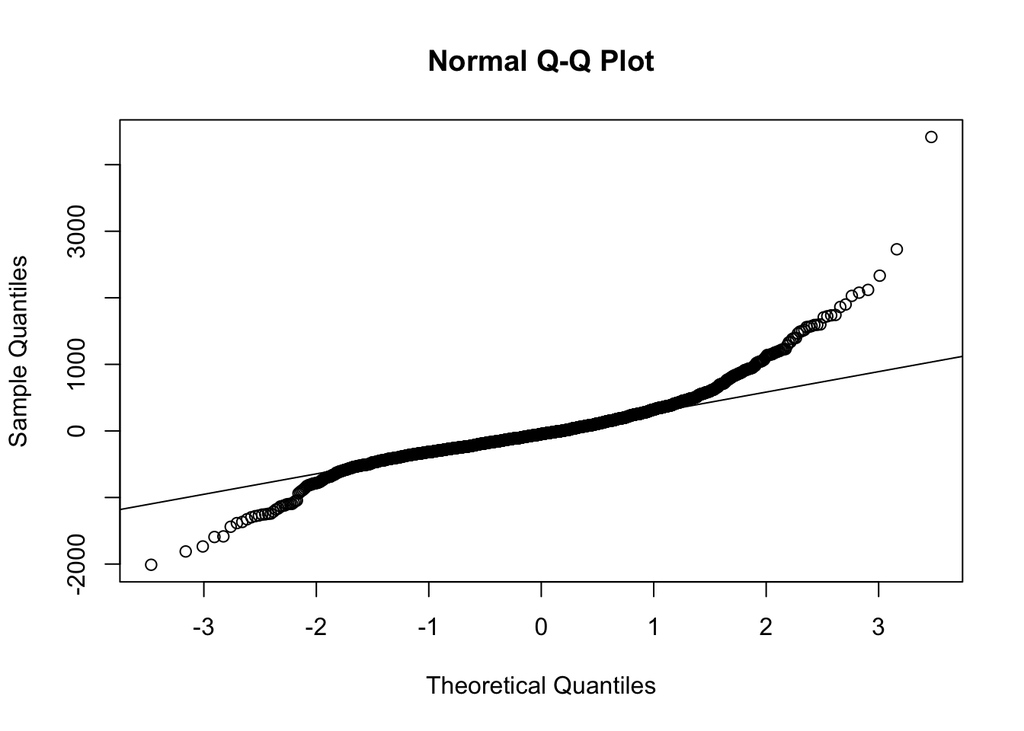

```r
qqnorm(residuals(model))
qqline(residuals(model))
```

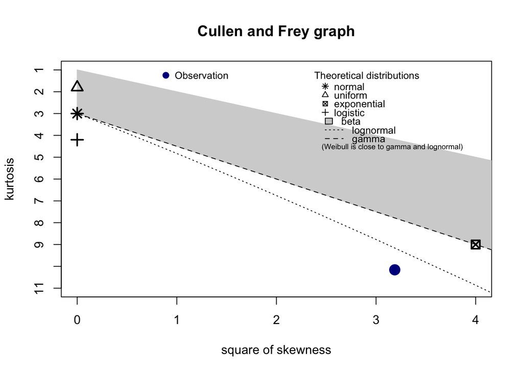

```
## summary statistics
## ------
## min:  85   max:  5679
## median:  1230
## mean:  1319.181
## estimated sd:  620.0185
## estimated skewness:  1.785423
## estimated kurtosis:  10.15902
```

```r
descdist(all_data_join$R5)
```

#Including covariates in the model. What does it loo klike when we start including our idividual difference measures? First we scale our measures of interest.

```r
#Let's include some covariates! Region 4

#Step 1: Scale the ID measures so as to be comparable.
all_data_join$SRS2_total_score_t <- scale(all_data_join$SRS2_total_score_t)
all_data_join$EQ <- scale(all_data_join$EQ)
all_data_join$WRMT_total_reading_score <- scale(all_data_join$WRMT_total_reading_score)
all_data_join$WRMT_WI_raw <- scale(all_data_join$WRMT_WI_raw)

# SINGULAR FIT
model_alldata <- lmer(R4 ~ cond + SRS2_total_score_t + EQ + WRMT_total_reading_score + WRMT_WI_raw +
                        (1 |subj) + (0 + SRS2_total_score_t|cond) +
                        (0 + EQ|cond) + (0 + WRMT_total_reading_score|cond) +
                        (0 + WRMT_WI_raw|cond) , all_data_join, REML = TRUE)
```

```
## boundary (singular) fit: see ?isSingular
```

```r
#Try again
#Simplified it loads and cannot get it to converge!
```